# Report about forestry levels over time

Yuchi Hsieh

2019/3/1

### This report focuses on data visualizations of global forestry levels over time. It presents the changing trend of average world-wide forested areas, the relationship between CO2 and forest area and the change in forest area levels for each country.

### Summary visualizations

[figure not shown]

Graphs below are intended to find out the relationship between **forest area** (% of land area) and **CO2 emissions** (metric tons per capita). Data are presented at a **four-year** interval(six facets). I calculated the average global CO2 emissions (the **mean** of world CO2 emissions from 1992 to 2014) by the data in World Bank to group all countries into two categorical variables which are **“over”** and **“equal or below the average”**. We can learn from this graph that there is **no clear relationship** between forest area and CO2 emissions for countries that have **lower CO2 level** but for countries that have **higher level of CO2**, there is **a weak negative relationship**. That is, forest area correlates to CO2 emissions for some extent.

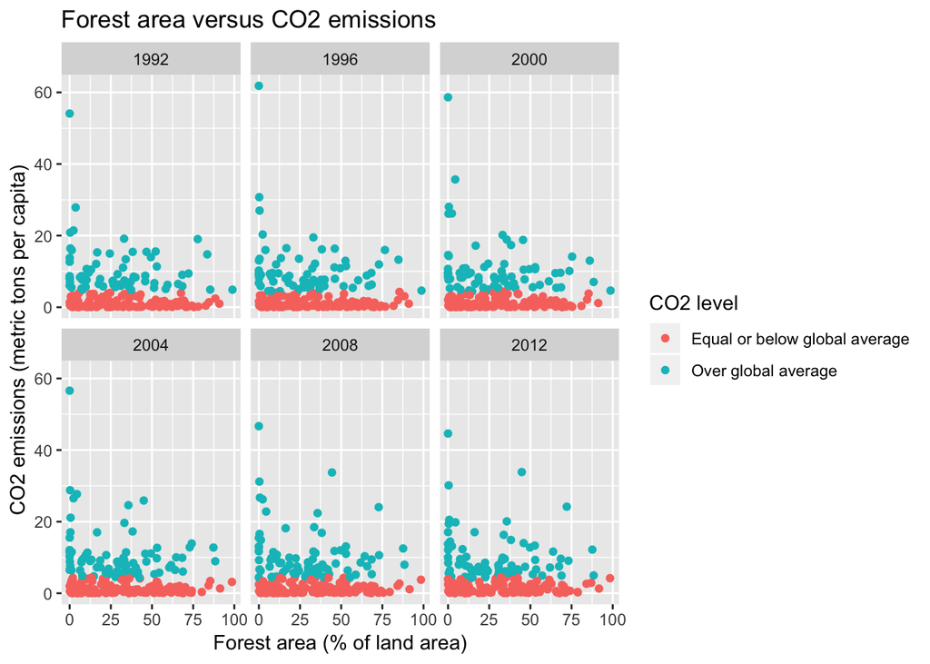

### Map showing changes of forest area

The map below shows the **forestry changes** for each country from 1992 to 2016. We can see from the map that most countries from Africa and South America have lost forest area slightly while most of the countries from Asia and Europe and US have gained forest area about 1-10 percent. Also, **a country from Africa** have had the **biggest lost** of forested area.

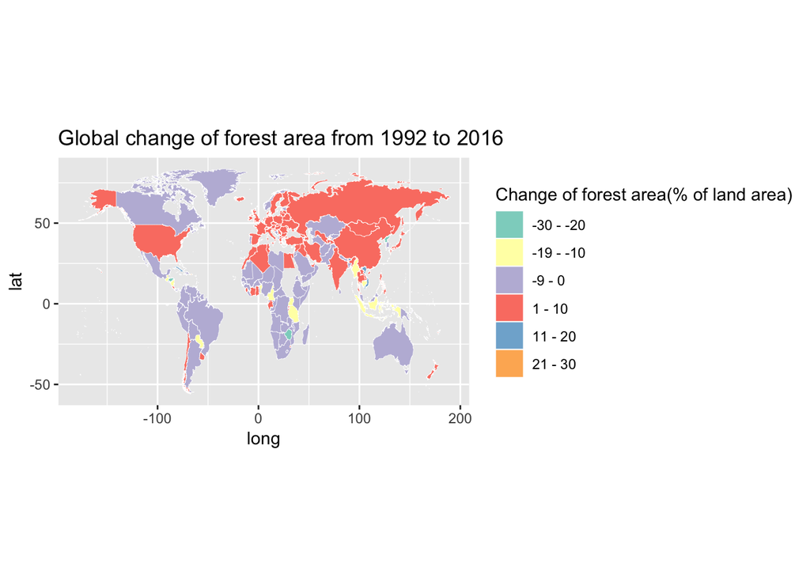

### Reference

- CO2 emissions(metric tons per capita), The World Bank, [link](https://data.worldbank.org/indicator/EN.ATM.CO2E.PC?end=2014&start=1992)